# Sheather Chapter 8: Logistic Regression

AG Schissler

17 Apr 2018

# Logistic regression based on a single predictor

## The binomial distribution

- $Y \sim Bin(m,\theta)$
- $m$ identical trials of experiment with two outcomes.
- The “success” outcome (coded as 1) occurs with probability $\theta$.
- $E(Y|m,\theta) = m\theta$
- $Var(Y|m,\theta) = m\theta (1-\theta)$
- For a single predictor $x_i$, we model the probability of success as a function of $x_i$:

$(Y|x_i) \sim Bin(m_i, \theta (x_i))$, $i=1,...,n$

Note that $y_i / m_i$ is an unbiased estimate of $\theta (x_i)$ and $y_i / m_i$ varies between 0 and 1.

## Motivating data set: MichelinFood

```
##   Food InMichelin NotInMichelin mi proportion
## 1   15          0             1  1       0.00
## 2   16          0             1  1       0.00
## 3   17          0             8  8       0.00
## 4   18          2            13 15       0.13
## 5   19          5            13 18       0.28
## 6   20          8            25 33       0.24
```

## The logistic function and odds

$log(\frac{\theta (x)}{1-\theta (x)}) = \beta_0 + \beta_1 x$ $\iff$ $\theta (x) = \frac{1}{1+exp(- \{\beta_0 + \beta_1 x\})}$

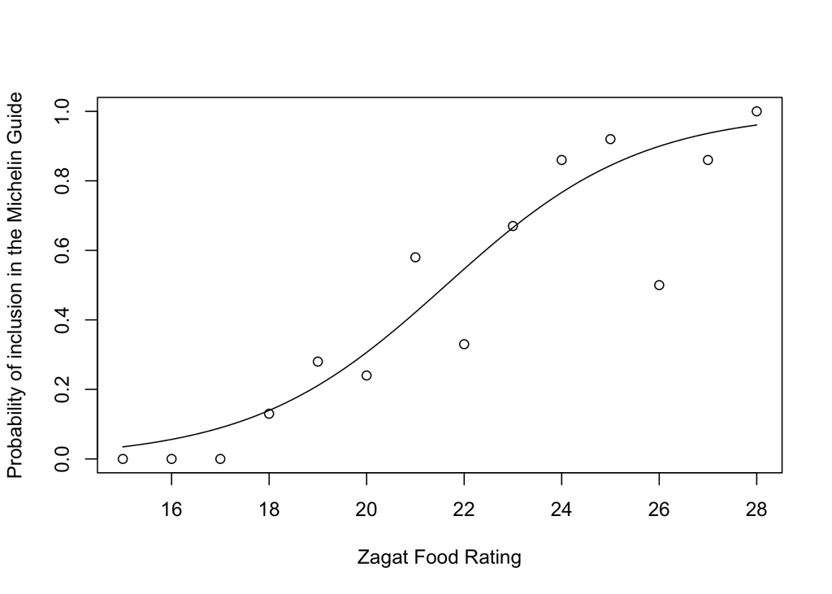

## Fitting a GLM with binomial response

```r
m1 <- glm(cbind(InMichelin,NotInMichelin)~Food,
          family=binomial, data = MichelinFood)
summary(m1)
```

```
##
## Call:
## glm(formula = cbind(InMichelin, NotInMichelin) ~ Food, family = binomial,
##     data = MichelinFood)
##
## Deviance Residuals:
##    Min      1Q  Median      3Q     Max
## -1.485  -0.799  -0.168   0.591   1.589
##
## Coefficients:
##             Estimate Std. Error z value Pr(>|z|)
## (Intercept) -10.8415     1.8624   -5.82  5.8e-09
## Food          0.5012     0.0877    5.72  1.1e-08
##
## (Dispersion parameter for binomial family taken to be 1)
##
##     Null deviance: 61.427  on 13  degrees of freedom
## Residual deviance: 11.368  on 12  degrees of freedom
## AIC: 41.49
##
## Number of Fisher Scoring iterations: 4
```

## Likelihood for logistic regression

- Parameter estimates are obtained via maximization of the log-likelihood
- Numeric methods must be used (no analytic solution)
- Parameter confidence intervals and hypothesis tests based on Wald test
- Marginal distribution is normal not $t$ as in MLR.

## Deviance $G^2$

- The concept of deviance replaces the concept of residual sum of squares ($RSS$) when maximum likelihood is used to fit.
- Think of it as the difference from a reduced model to a full (saturated) model.
- Deviance has a $\chi^2_{n-p-1}$ distribution when each $m_i$ is large enough.
- This can be used as a goodness-of-fit diagnostic. Or a model comparison tool…

## Model comparison through difference in deviance

```r
#Value of the difference in devinace and associated p-value on page 273
m1$null.deviance-m1$deviance
```

```
## [1] 50.059
```

```r
## one degree of freedom since the null deviance has only an intercept
pchisq(m1$null.deviance-m1$deviance,1,lower=FALSE)
```

```
## [1] 1.4922e-12
```

## $R^2$ for logistic regression

$R^2_{dev}=1 - \frac{G^2_{H_A}}{G^2_{H_0}}$

## Residuals for logistic regression

Three types of residuals:

- Response residuals
- Pearson residuals and Pearson standardized residuals
- Deviance residuals and Deviance standardized residuals

Main takeaway is to use standardized Pearson or Deviance residuals.

Standardized deviance residuals is slightly preferred.

Residual analysis proceeds as in the MLR case.

# Binary logistic regression

- Most often in practice one does not observe multiple trials at each predictor.
- This means that $m_i=1$ for all $i$.
- Unfortunately this complicates the measures of deviance and goodness-of-fit.
- and also the residuals become difficult to interpret.

```
##   InMichelin Restaurant.Name Food Decor Service Price
## 1          0  14 Wall Street   19    20      19    50
## 2          0             212   17    17      16    43
## 3          0        26 Seats   23    17      21    35
## 4          1              44   19    23      16    52
## 5          0               A   23    12      19    24
## 6          0          A.O.C.   18    17      17    36
```

## Plot of data with logistic and loess fit

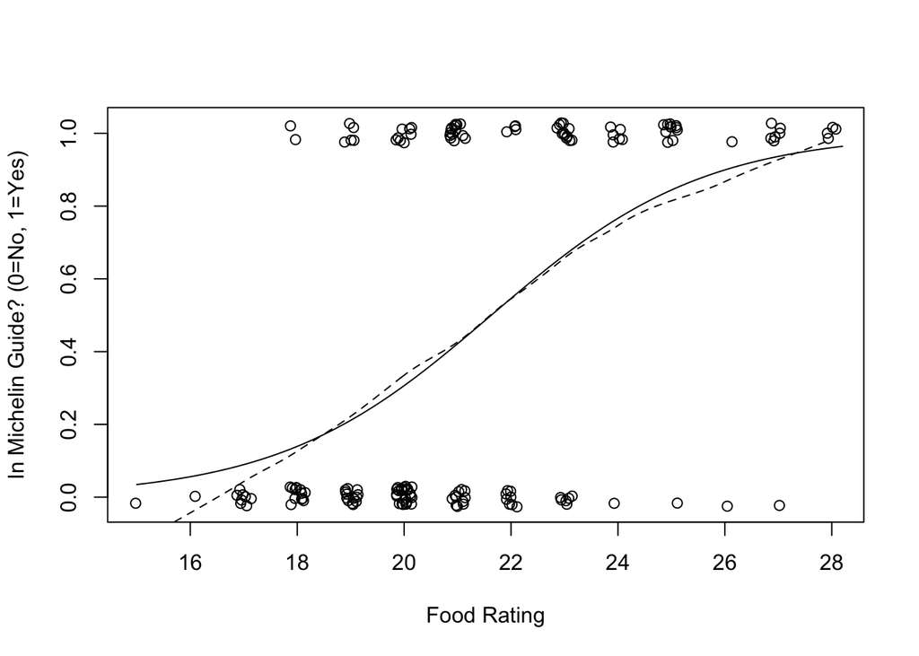

## Deviance for the case of binary data

- Since $m_i=1$ always, the deviance no longer has the distribution needed to assess the goodness-of-fit (that a logistic model is a good choice).
- But the good news is that the difference in deviances is still chi-squared.
- See the nice analysis on p.280 for details.

## Residuals for Binary data

- (Standardized) residuals can have a non-random pattern even if the model is correct.
- One solution is to aggregate as in the previous section, but this doesn’t work well when you have a large number of predictors.
- Another solution is to compare to nonparametrics (as in the marginal model plots).
- Or you can transform the predictors…

## Transforming predictors for binary

- The main idea is that if your predictors follow certain distributions, then you can analytically determine what transformations to perform and terms to include.
- If your predictor $X$ is normally distributed with the same variance for each case of $Y$, then no transformation is needed.
- If your predictor $X$ is normally distributed with different variances for each case of $Y$, then the log odds are a quadratic function of $x$. More generally, if you have more than one $x$ then you need to include the interaction $x_i x_j$.

## Transforming predictors for binary (con’d)

- If your predictor $x$ is Gamma (or other skewed variable), then a $log(x)$ must be included.
- The general advice is to plot your variables and then decide whether to transform (via box-cox) or include quadratic/crossterms or log terms.
- Even still the residuals are difficult to interpret.
- So Sheather recommends just using nonparametric comparisons.

## Marginal model plots for binary

- Follow the recommendations based on your predictor’s distributions (e.g., include log(x) term or quadratic term).
- Then create marginal model plots for each predictor and inspect.

## Marginal model plots for binary

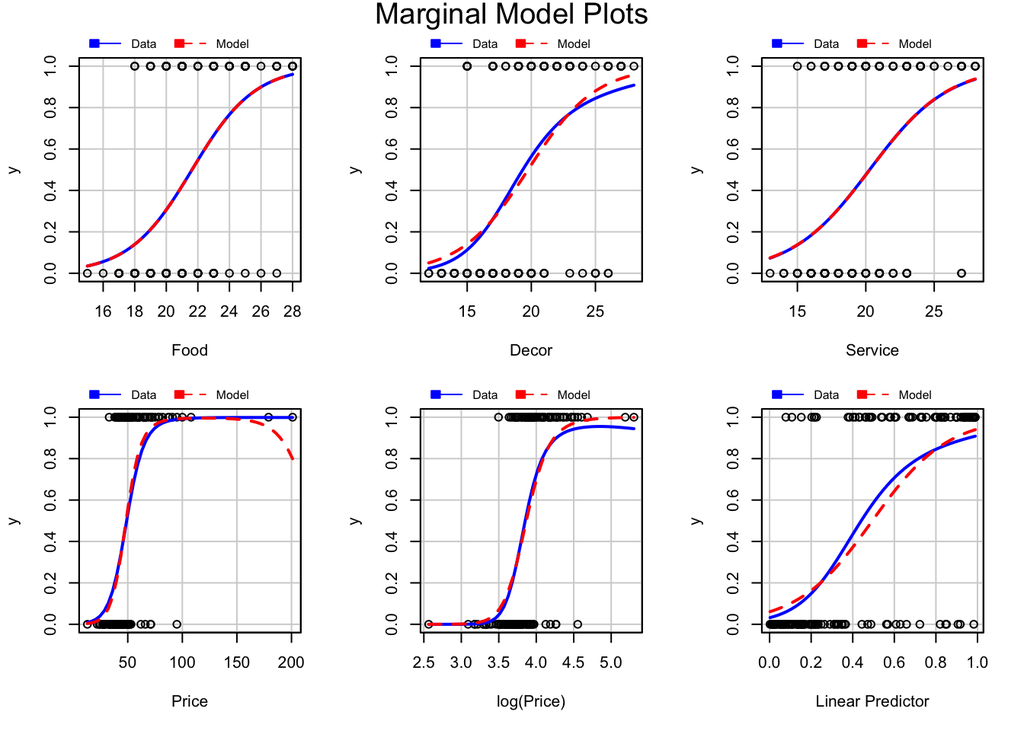

```r
m2 <- glm( y~Food + Decor + Service + Price + log(Price),
          family=binomial(),data=MichelinNY )
car::mmps(m2,layout=c(2,3))
```